# R Notebook

```r
# read the CSV file for class project
stocks <-read.csv("data copy.csv")
```

```r
# Part 1 ----

# summary statistics for each variable

# sample mean for each variable
mean(stocks$Close_ETF)
```

```
[1] 121.153
```

```r
mean(stocks$oil)
```

```
[1] 0.001030035
```

```r
mean(stocks$gold)
```

```
[1] 0.0006628361
```

```r
mean(stocks$JPM)
```

```
[1] 0.000530411
```

```r
# standard deviation for each variable
sd(stocks$Close_ETF)
```

```
[1] 12.56979
```

```r
sd(stocks$oil)
```

```
[1] 0.0210929
```

```r
sd(stocks$gold)
```

```
[1] 0.01128906
```

```r
sd(stocks$JPM)
```

```
[1] 0.01101656
```

```r
# sample correlations between each pair
cor(stocks$Close_ETF, stocks$oil)
```

```
[1] -0.009044843
```

```r
cor(stocks$Close_ETF, stocks$gold)
```

```
[1] 0.02299557
```

```r
cor(stocks$Close_ETF, stocks$JPM)
```

```
[1] 0.03680706
```

```r
cor(stocks$oil, stocks$gold)
```

```
[1] 0.2356504
```

```r
cor(stocks$oil, stocks$JPM)
```

```
[1] -0.1208489
```

```r
cor(stocks$gold, stocks$JPM)
```

```
[1] 0.1001698
```

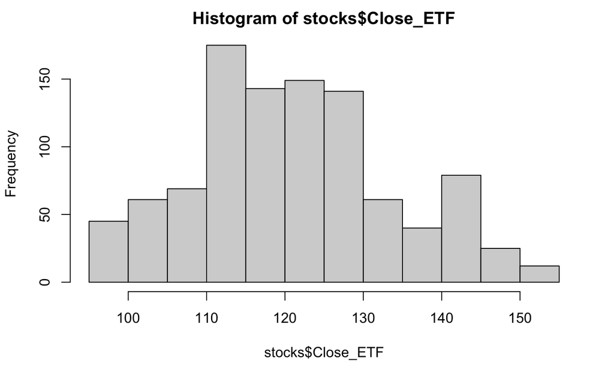

```r
# Part 2 ----

# create histograms for each variable
hist(stocks$Close_ETF)
```

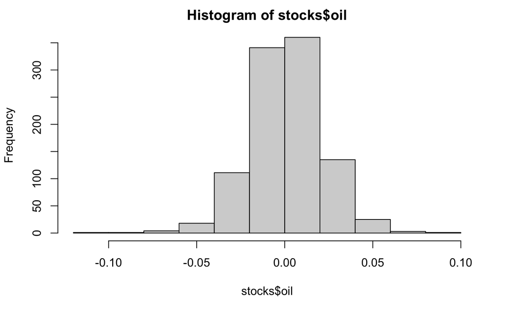

```r
hist(stocks$oil)
```

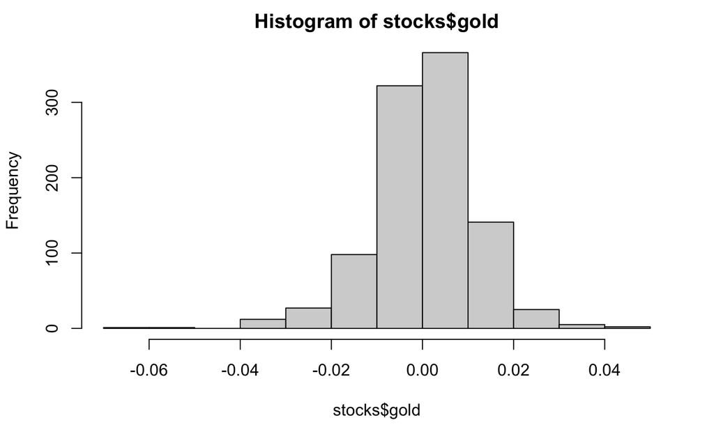

```r
hist(stocks$gold)
```

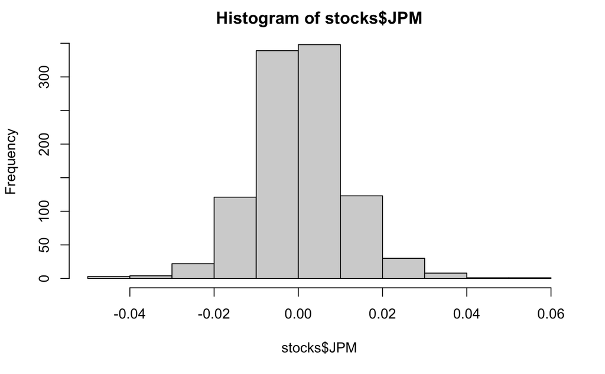

```r
hist(stocks$JPM)
```

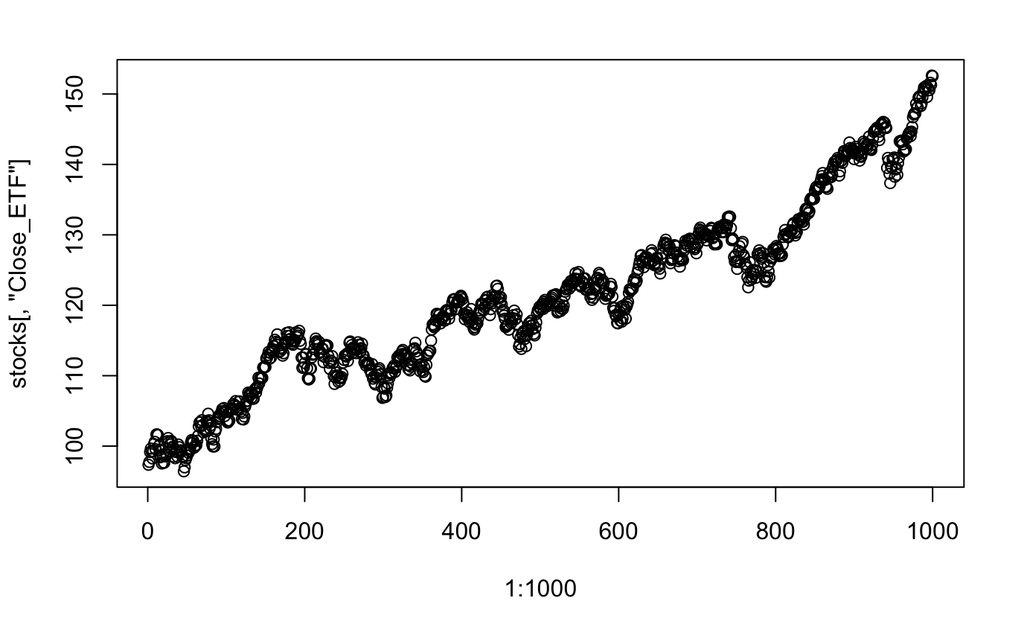

```r
#time series plot for each variable
plot(1:1000, stocks[, "Close_ETF"])
```

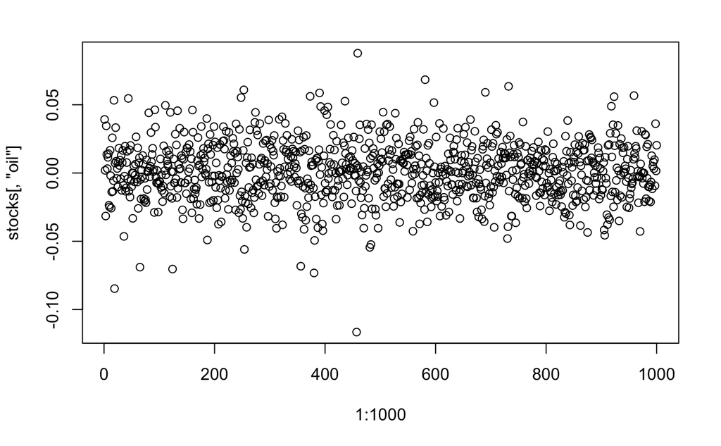

```r
plot(1:1000, stocks[, "oil"])
```

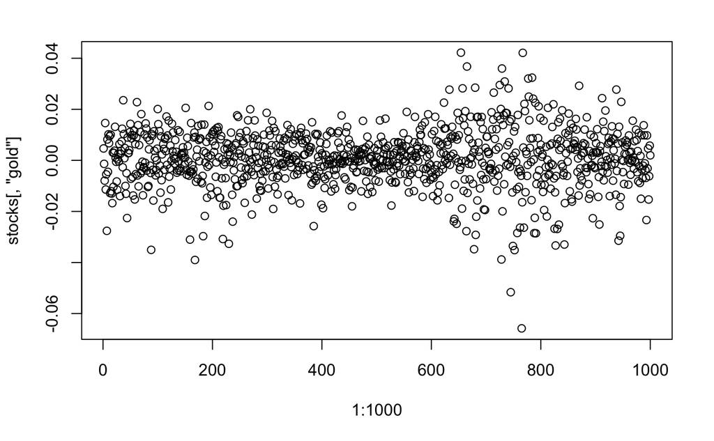

```r
plot(1:1000, stocks[, "gold"])
```

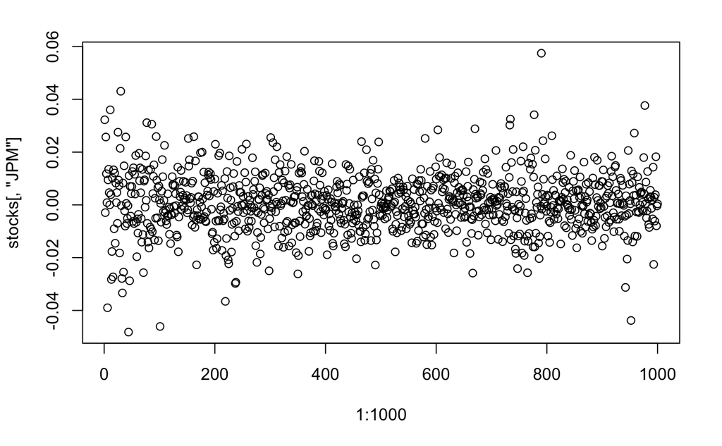

```r
plot(1:1000, stocks[, "JPM"])
```

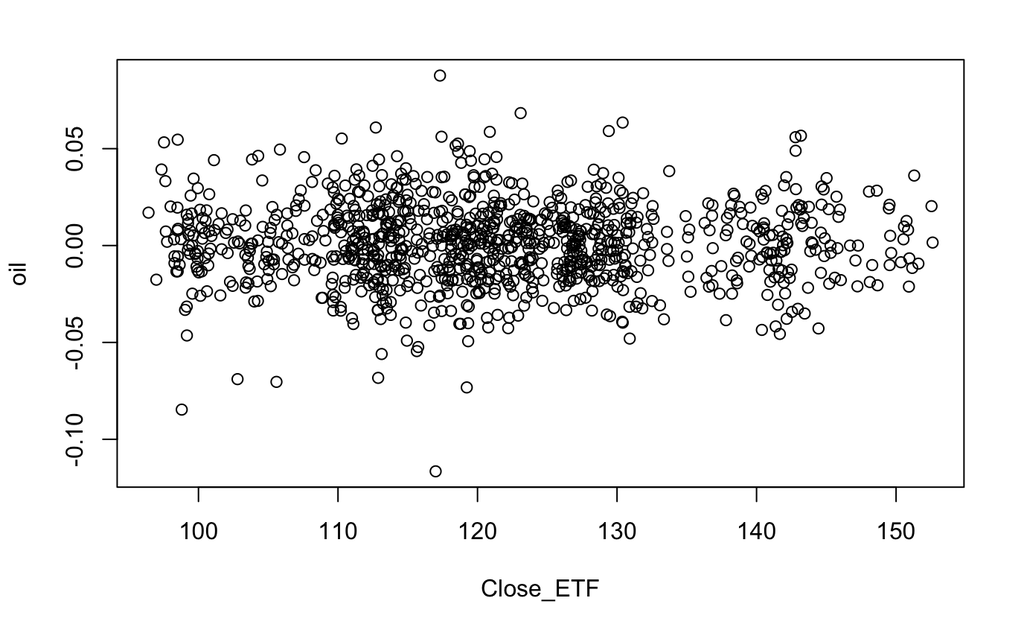

```r
# scatter plots
plot(stocks[, 1:2])
```

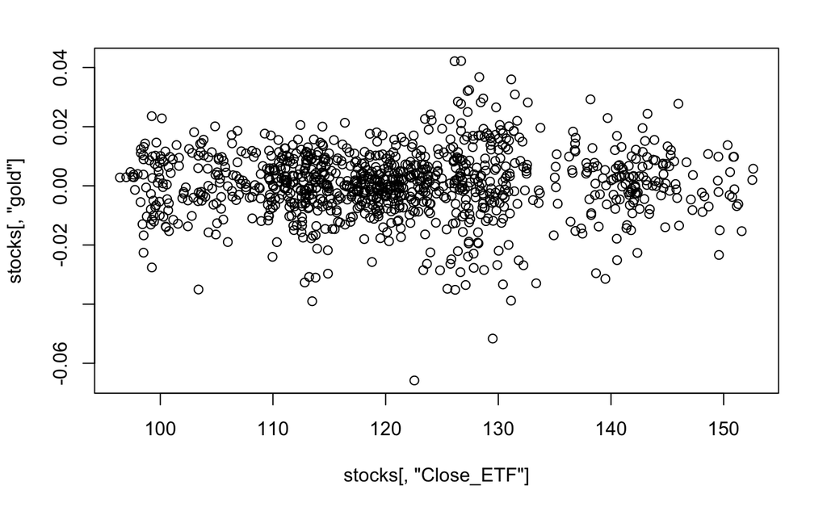

```r
plot(stocks[, "Close_ETF"], stocks[, "gold"])
```

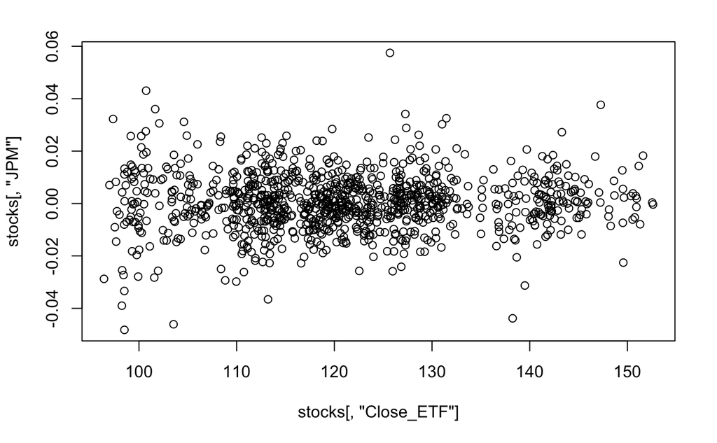

```r
plot(stocks[, "Close_ETF"], stocks[, "JPM"])
```

```r
# Part 4 ----

# Step 8, Generate 50 simple random samples (with replacement), size = 20

rm(.Random.seed)
sample(stocks$Close_ETF, 20, replace=TRUE)
```

```
 [1] 129.65 123.67 118.44 113.13  99.65 148.62 130.87 123.54 130.03 151.60 121.47 103.41
[13] 117.42 120.37 116.07  98.50 138.58 132.62 110.84 138.25
```

```r
# Step 10, Generate 10 simple random samples (with replacement), size = 100
sample(stocks$Close_ETF, 100, replace=TRUE)
```

```
  [1] 124.00 120.88 120.76 130.56 109.77 118.10 142.00 110.20 113.77 148.29 103.68 112.24
 [13] 109.75 111.81 120.24 126.66 120.30 115.99 123.49 117.82 121.57  99.56 104.72 138.58
 [25] 118.79 141.07 114.80 113.21 122.27 114.20 123.76 139.62 129.83 119.27 112.58 130.43
 [37] 140.02 107.00 113.15 117.28 125.97 150.35 130.18 125.35 148.06 139.50 127.80 129.76
 [49] 113.22 113.55 103.54 127.41 111.86 118.09 122.33 126.13  96.42 117.23 124.46 127.37
 [61] 145.32 141.54 118.73 123.34 144.44 117.14 127.10 119.11 115.20 119.41 112.88 146.04
 [73] 127.90 129.76 117.58 121.05 139.62 126.33 103.38 119.15 127.01 119.50 104.00 127.38
 [85] 122.79 122.47 124.35 105.41 139.50 128.17 130.12 119.95 114.80 112.96 118.10 130.37
 [97] 114.75 124.99 115.66 110.20
```

```r
# Part 5 ----

# Selection of one group from Part 4 Step 10

ETF6 <- c(111.120003, 145.800003, 119.209999, 138.080002, 143.199997, 123.389999, 129.649994, 115.650002, 126.330002,
          120.389999, 112.440002, 121.690002, 150.529999, 107, 103.629997, 114.199997, 119.779999, 113.220001, 143.75,
          108.75, 118, 100.110001, 99.949997, 144.020004, 130.619995, 122.550003, 142.050003, 99.440002, 127.440002,
          114.199997, 119.480003, 133.580002, 144.610001, 120.5, 114.389999, 131.380005, 128.770004, 112.580002,
          148.669998, 120.230003, 110.75, 123.330002, 130.559998, 128.380005, 140.919998, 115.870003, 110.349998,
          100.230003, 120.129997, 111.160004, 111.160004, 99.160004, 126.660004, 120.870003, 147.089996, 127.410004,
          111.120003, 128.630005, 110.199997, 131.360001, 117.300003, 115.989998, 130.279999, 111.199997, 142.339996,
          123.089996, 99.389999, 120.860001, 118.959999, 119.230003, 117.82, 109.650002, 135.009995, 120.209999,
          125.760002, 131.869995, 126.230003, 131.130005, 132.139999, 105.040001, 126.300003, 127.82, 121.400002,
          130.210007, 122.239998, 115.129997, 100.279999, 109.959999, 122.110001, 112.970001, 113.370003, 150.860001,
          118.089996, 115.099998, 118.099998, 113.389999, 114.589996, 111.919998, 114.589996, 114.230003)
```

```r
length(ETF6)
```

```
[1] 100
```

```r
# Question 1 - 95% Confidence Intervals
a <- mean(ETF6)
s <- sd(ETF6)
n <- 100
error <- qnorm(0.975) * s / sqrt(n)
left <- a - error
right <- a + error
left
```

```
[1] 119.0775
```

```r
right
```

```
[1] 123.9601
```

```r
# Question 2 - 95% Confidence Intervals
# Selection of one group from Part 4 Step 8
ETF26 <- c(117.5, 127.980003, 130.509995, 112.82, 114.25, 128.770004, 141.070007, 113.650002, 123.330002, 144.660004,
           128.309998, 108.910004, 98.279999, 126.830002, 124.720001, 109.650002, 122.230003, 138.240005, 118.099998,
           114.389999)
```

```r
length(ETF26)
```

```
[1] 20
```

```r
# Question 2 - 95% Confidence Intervals

a1 <- mean(ETF26)
s1 <- sd(ETF26)
n1 <- 100
error1 <- qnorm(0.975) * s1 / sqrt(n1)
left1 <- a1 - error
right1 <- a1 + error
left1
```

```
[1] 119.7687
```

```r
right1
```

```
[1] 124.6513
```

The mean from Part 1 = 121.1530. The population mean fits within both sets of confidence intervals. The confidence interval calculated from the data set with n = 100, (119.0775, 123.9601) would be more accurate since it was calculated from a larger data set.

```r
# Part 6 ----

# 1. 2 - sided T-test on Sample Set ETF6, H0: u = 100 at Confidence Level = 95%
t.test(ETF6, mu = 100)
```

```
    One Sample t-test

data:  ETF6
t = 17.276, df = 99, p-value < 2.2e-16
alternative hypothesis: true mean is not equal to 100
95 percent confidence interval:
 119.0473 123.9903
sample estimates:
mean of x
 121.5188
```

The t-test result does not support the H0: u = 100 as the p-value is extremely small and < significance level of 0.05. Therefore, the data set’s mean, selected in Part 5, Step 1, is not equal to 100.

```r
# 2. 2-sided T-test on Sample Set ETF26, H0: u = 100 at Confidence Level = 95%
t.test(ETF26, mu = 100)
```

```
    One Sample t-test

data:  ETF26
t = 8.5565, df = 19, p-value = 6.086e-08
alternative hypothesis: true mean is not equal to 100
95 percent confidence interval:
 116.7771 127.6429
sample estimates:
mean of x
   122.21
```

The t-test result does not support the H0: u = 100 as the p-value is extremely small and < significance level of 0.05. Therefore, the data set’s mean, selected in Part 5, Step 2, is not equal to 100.

```r
install.packages("EnvStats")
```

```
Error in install.packages : Updating loaded packages
```

```r
library(EnvStats)
# 3. 2-sided Chi-Squared Test on Sample Set ETF26, sigma = 225 at Confidence Level = 95%
varTest(ETF26, sigma.squared = 225)
```

```
    Chi-Squared Test on Variance

data:  ETF26
Chi-Squared = 11.379, df = 19, p-value = 0.1792
alternative hypothesis: true variance is not equal to 225
95 percent confidence interval:
  77.93401 287.46522
sample estimates:
variance
134.7534
```

In order to run the Chi-Squared test, I set the variance to 225 (i.e. 15 x 15) The Chi-Squared Test result supports the H0: σ = 15 as the p-value > significance level.

```r
# 4. 1-sided Chi-Sqaured Test on Sample Set ETF25, sigma = 225 at Conficence Level = 95%
varTest(ETF26, alternative = "less", sigma.squared = 225)
```

```
    Chi-Squared Test on Variance

data:  ETF26
Chi-Squared = 11.379, df = 19, p-value = 0.08958
alternative hypothesis: true variance is less than 225
95 percent confidence interval:
   0.0000 253.0701
sample estimates:
variance
134.7534
```

The Chi-Squared Test result supports the H0: σ = 15 as the p-value > significance level.